# Class12

## set up BioConductor DESeq2

```r
install.packages("BiocManager")
BiocManager::install()
BiocManager::install("DESeq2")
```

## Data for today’s class saved into the project

```r
counts<- read.csv("airway_scaledcounts.csv", stringsAsFactors = FALSE)
metadata<- read.csv("airway_metadata.csv", stringsAsFactors = FALSE)
```

## let’s have a peak

```r
head(counts)
```

```
##           ensgene SRR1039508 SRR1039509 SRR1039512 SRR1039513 SRR1039516
## 1 ENSG00000000003        723        486        904        445       1170
## 2 ENSG00000000005          0          0          0          0          0
## 3 ENSG00000000419        467        523        616        371        582
## 4 ENSG00000000457        347        258        364        237        318
## 5 ENSG00000000460         96         81         73         66        118
## 6 ENSG00000000938          0          0          1          0          2
##   SRR1039517 SRR1039520 SRR1039521
## 1       1097        806        604
## 2          0          0          0
## 3        781        417        509
## 4        447        330        324
## 5         94        102         74
## 6          0          0          0
```

### how many genes do we have

```r
nrow(counts)
```

```
## [1] 38694
```

### how many experiments

```r
ncol(counts)-1
```

```
## [1] 8
```

### what are our controls ??? we check the metadata

### let’s make sure the metadata ID col matches the colnames of counts

```r
colnames(counts)[-1]
```

```
## [1] "SRR1039508" "SRR1039509" "SRR1039512" "SRR1039513" "SRR1039516"
## [6] "SRR1039517" "SRR1039520" "SRR1039521"
```

```r
metadata$id
```

```
## [1] "SRR1039508" "SRR1039509" "SRR1039512" "SRR1039513" "SRR1039516"
## [6] "SRR1039517" "SRR1039520" "SRR1039521"
```

```r
(colnames(counts)[-1])== (metadata$id)
```

```
## [1] TRUE TRUE TRUE TRUE TRUE TRUE TRUE TRUE
```

### if you have a lage metadata you can condense it

```r
all((colnames(counts)[-1])== (metadata$id))
```

```
## [1] TRUE
```

## analysis compare the control to drug tested

## first we need ot access the columns of our countDaa that are control and find their mean

```r
metadata$dex
```

```
## [1] "control" "treated" "control" "treated" "control" "treated" "control"
## [8] "treated"
```

### but i want the specific columns to access!!!

```r
control_id<-metadata[ metadata$dex=="control", ]$id
control_id
```

```
## [1] "SRR1039508" "SRR1039512" "SRR1039516" "SRR1039520"
```

```r
head(counts[ ,control_id])
```

```
##   SRR1039508 SRR1039512 SRR1039516 SRR1039520
## 1        723        904       1170        806
## 2          0          0          0          0
## 3        467        616        582        417
## 4        347        364        318        330
## 5         96         73        118        102
## 6          0          1          2          0
```

#### ok we want the mean across the control rows!!!

```r
control_mean<-rowSums(counts[,control_id])/(length(control_id))
names(control_mean)<- counts$ensgene
```

## now for the treated

```r
treated_id<-metadata[ metadata$dex=="treated", ]$id
treated_id
```

```
## [1] "SRR1039509" "SRR1039513" "SRR1039517" "SRR1039521"
```

```r
head(counts[ ,treated_id])
```

```
##   SRR1039509 SRR1039513 SRR1039517 SRR1039521
## 1        486        445       1097        604
## 2          0          0          0          0
## 3        523        371        781        509
## 4        258        237        447        324
## 5         81         66         94         74
## 6          0          0          0          0
```

##now for the treated

```r
treated_mean<-rowSums(counts[,treated_id])/(length(treated_id))
names(treated_mean)<- counts$ensgene
```

### store them together!!

```r
meancounts<- data.frame(control_mean, treated_mean)
```

### plot control vs tested!!

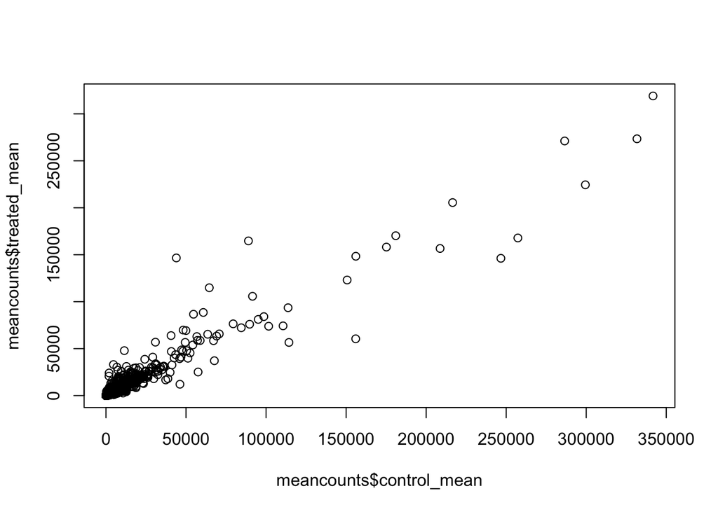

```r
plot(meancounts$control_mean, meancounts$treated_mean)
```

### well that’s no good!!! so let’s plot it on a log scale (bc like, only a few have high expression! so it willbe easier to visualize)

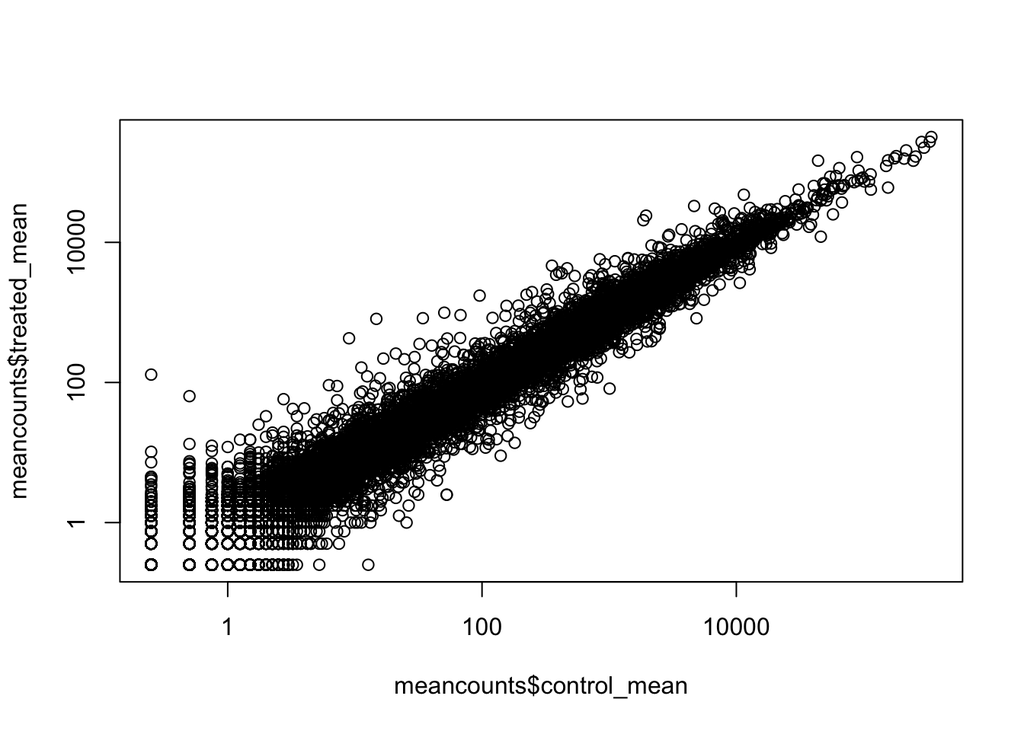

```r
plot(meancounts$control_mean, meancounts$treated_mean, log="xy")
```

## points that are abberant (have differential expression) are noticably above or below the dark center line

### now lets get the fold change! if fold change is 0 then there was no difference

```r
meancounts$log2fc <- log2(meancounts[,"treated_mean"]/meancounts[,"control_mean"])
head(meancounts)
```

```
##                 control_mean treated_mean      log2fc
## ENSG00000000003       900.75       658.00 -0.45303916
## ENSG00000000005         0.00         0.00         NaN
## ENSG00000000419       520.50       546.00  0.06900279
## ENSG00000000457       339.75       316.50 -0.10226805
## ENSG00000000460        97.25        78.75 -0.30441833
## ENSG00000000938         0.75         0.00        -Inf
```

#### the next step is to EXCLUDE THE 0 VALUES!!! we DON’T WANT THEM!!!

```r
x<- data.frame(happy=c(5,0,4,3), sad=c(0,5,5,0))
x==0
```

```
##      happy   sad
## [1,] FALSE  TRUE
## [2,]  TRUE FALSE
## [3,] FALSE FALSE
## [4,] FALSE  TRUE
```

```r
which(x==0, arr.ind =TRUE)
```

```
##      row col
## [1,]   2   1
## [2,]   1   2
## [3,]   4   2
```

```r
unique(which(x==0, arr.ind =TRUE)[,1])
```

```
## [1] 2 1 4
```

## now let’s apply this to our counts!

```r
#which(meancounts==0, arr.ind = TRUE)
to_rm<-unique(which(meancounts[,1:2]==0, arr.ind =TRUE)[,1])
zero_vals <- which(meancounts[,1:2]==0, arr.ind=TRUE)

to.rm <- unique(zero_vals[,1])
mycounts <- meancounts[-to.rm,]
head(mycounts)
```

```
##                 control_mean treated_mean      log2fc
## ENSG00000000003       900.75       658.00 -0.45303916
## ENSG00000000419       520.50       546.00  0.06900279
## ENSG00000000457       339.75       316.50 -0.10226805
## ENSG00000000460        97.25        78.75 -0.30441833
## ENSG00000000971      5219.00      6687.50  0.35769358
## ENSG00000001036      2327.00      1785.75 -0.38194109
```

### fold change time !!! we have set a threshold

```r
up.ind <- mycounts$log2fc > 2
down.ind <- mycounts$log2fc < (-2)
```

```r
sum(up.ind)
```

```
## [1] 250
```

```r
head( mycounts[up.ind,] )
```

```
##                 control_mean treated_mean   log2fc
## ENSG00000004799       270.50      1429.25 2.401558
## ENSG00000006788         2.75        19.75 2.844349
## ENSG00000008438         0.50         2.75 2.459432
## ENSG00000011677         0.50         2.25 2.169925
## ENSG00000015413         0.50         3.00 2.584963
## ENSG00000015592         0.50         2.25 2.169925
```

```r
#columns(org.Hs.eg.db)
#mycounts$symbol <- mapIds(org.Hs.eg.db,
                     #keys=row.names(mycounts), # Our genenames
                     #keytype="ENSEMBL",        # The format of our genenames
                     #column="SYMBOL",          # The new format we want to add
                     #multiVals="first")
#head(mycounts)
```

### we are gonna make our summary plot!!

### also hey remember that fold change is great but you need it to be significant! let’s work with that

### DESeq Analysis

```r
library(DESeq2)
## ok time to do some DESeq
#set up our obejct for DESeq analysis

dds <- DESeqDataSetFromMatrix(countData=counts,
                              colData=metadata,
                              design=~dex,
                              tidy=TRUE)
dds
```

```
## class: DESeqDataSet
## dim: 38694 8
## metadata(1): version
## assays(1): counts
## rownames(38694): ENSG00000000003 ENSG00000000005 ...
##   ENSG00000283120 ENSG00000283123
## rowData names(0):
## colnames(8): SRR1039508 SRR1039509 ... SRR1039520 SRR1039521
## colData names(4): id dex celltype geo_id
```

```r
dds<- DESeq(dds)
res<-results(dds)
res
```

```
## log2 fold change (MLE): dex treated vs control
## Wald test p-value: dex treated vs control
## DataFrame with 38694 rows and 6 columns
##                          baseMean     log2FoldChange             lfcSE
##                         <numeric>          <numeric>         <numeric>
## ENSG00000000003  747.194195359907 -0.350703020686579 0.168245681332529
## ENSG00000000005                 0                 NA                NA
## ENSG00000000419  520.134160051965  0.206107766417861 0.101059218008052
## ENSG00000000457  322.664843927049 0.0245269479387471 0.145145067649248
## ENSG00000000460   87.682625164828  -0.14714204922212 0.257007253994673
## ...                           ...                ...               ...
## ENSG00000283115                 0                 NA                NA
## ENSG00000283116                 0                 NA                NA
## ENSG00000283119                 0                 NA                NA
## ENSG00000283120 0.974916032393564  -0.66825846051647  1.69456285241871
## ENSG00000283123                 0                 NA                NA
##                               stat             pvalue              padj
##                          <numeric>          <numeric>         <numeric>
## ENSG00000000003   -2.0844696749953 0.0371174658432827 0.163034808641681
## ENSG00000000005                 NA                 NA                NA
## ENSG00000000419    2.0394751758463 0.0414026263001167 0.176031664879168
## ENSG00000000457  0.168982303952746  0.865810560623561 0.961694238404388
## ENSG00000000460  -0.57252099672319  0.566969065257939 0.815848587637724
## ...                            ...                ...               ...
## ENSG00000283115                 NA                 NA                NA
## ENSG00000283116                 NA                 NA                NA
## ENSG00000283119                 NA                 NA                NA
## ENSG00000283120 -0.394354484734893  0.693319342566817                NA
## ENSG00000283123                 NA                 NA                NA
```

```r
summary(res)
```

```
##
## out of 25258 with nonzero total read count
## adjusted p-value < 0.1
## LFC > 0 (up)       : 1563, 6.2%
## LFC < 0 (down)     : 1188, 4.7%
## outliers [1]       : 142, 0.56%
## low counts [2]     : 9971, 39%
## (mean count < 10)
## [1] see 'cooksCutoff' argument of ?results
## [2] see 'independentFiltering' argument of ?results
```

### cool let’s plot it!!!

#VOLCANO PLOT

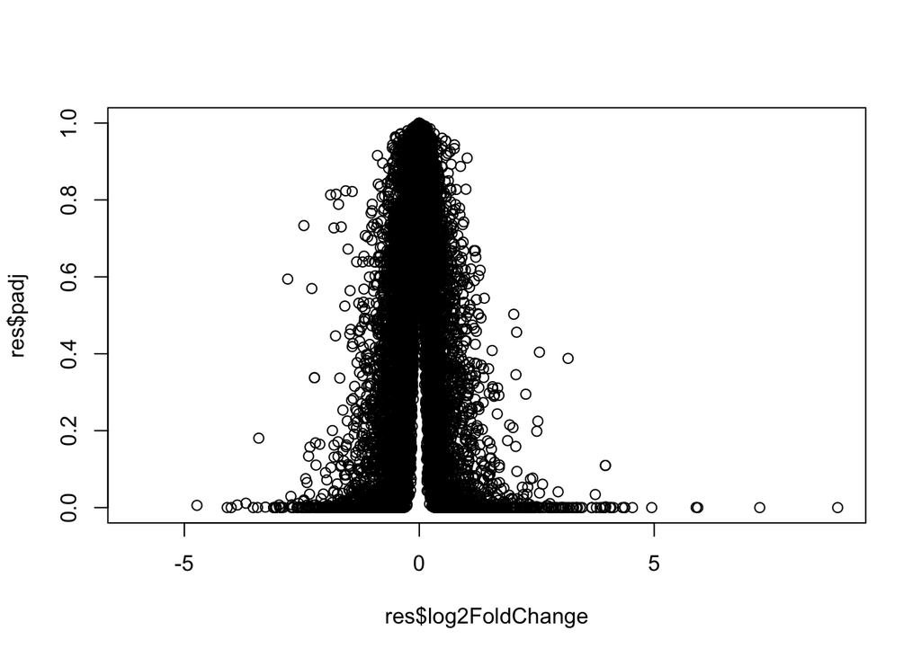

```r
plot(res$log2FoldChange, res$padj)
```

### ok but that’s no good! we want to see the small p values easily!! #take the log! but the -log of res$padj # in this way, the larger numbers are the smallest p values

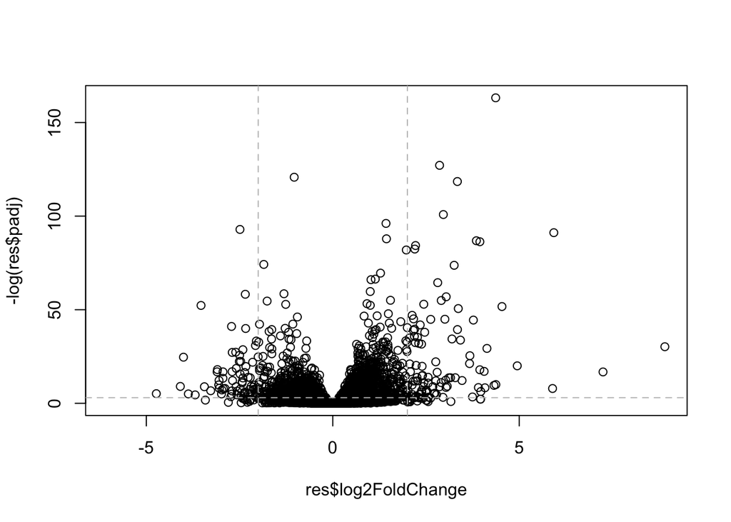

```r
plot(res$log2FoldChange, -log(res$padj))
abline(v=c(-2,2), col="gray", lty=2)
abline(h=-log(0.05), col="gray", lty=2)
```

#### let’s color it

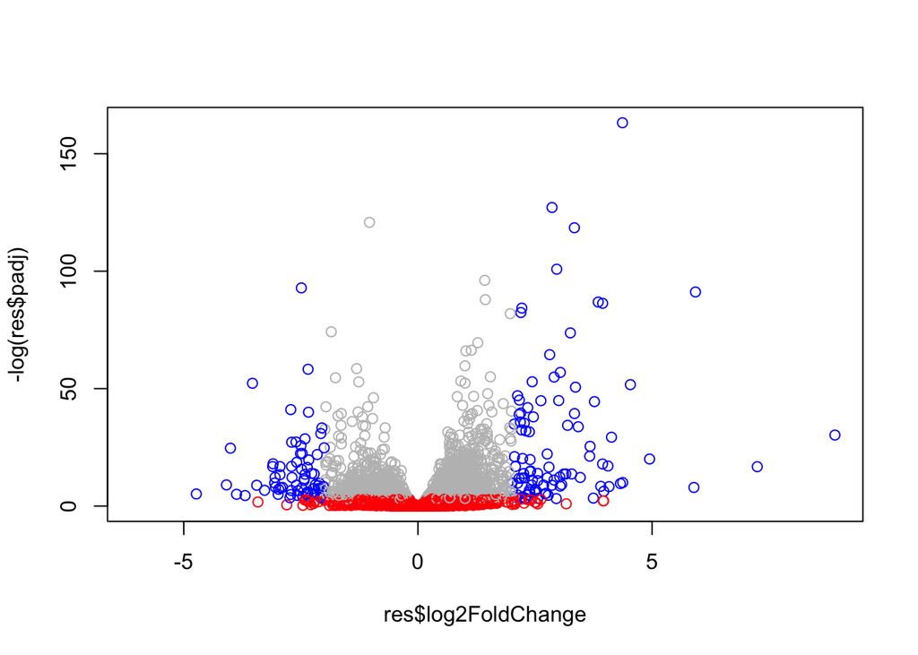

```r
mycols<- rep("grey", length(res$padj))
mycols[abs(res$log2FoldChange)>2]= "blue"
mycols[ res$padj > 0.05 ]="red"
plot(res$log2FoldChange, -log(res$padj), col=mycols)
```